# Activity Monitoring Data Analysis

### Question 3: With missing values imputed, what are the mean and median total number of steps taken per day?

#### Imputing missing values

In the previous analyses, we simply ignored any missing/NA values. To understand whether or not this could cause data skew, we first want to calculate the number of NA values in the dataset.

```r
naCount<-sum(is.na(activityData$steps))
naPercent<-100*(naCount/dim(activityData)[1])
```

Given that number of missing values is 2304 which represents 13.1147541% of the data, for the following analyses we will attempt to interpolate these values in order to ensure that the data is less biased towards certain dates or times.

To attempt to account for both the variance over days and the variance over time-of-day, we will simply replace the missing values with the averaged daily activity pattern values.

With the above algorithm applied, the histogram of the total steps taken has changed to:

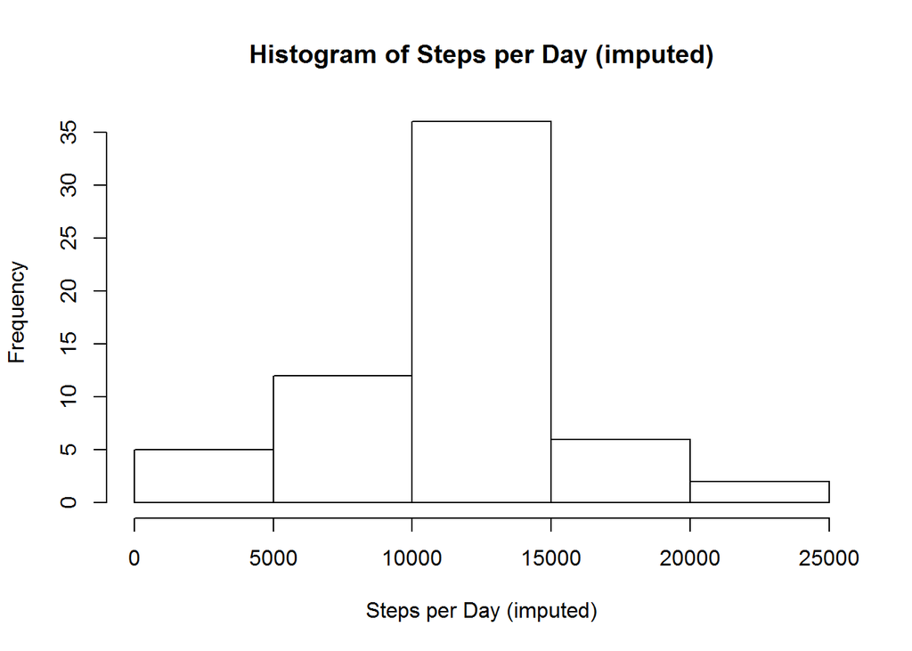

### Question 4: With missing values imputed, are there differences between activity patterns between weekdays and weekends?

First, we add a column to our (imputed) dataset which tells us whether the date is a weekday or a weekend.

Then we can aggregate the data by interval and plot it using two panels in a time series plot:

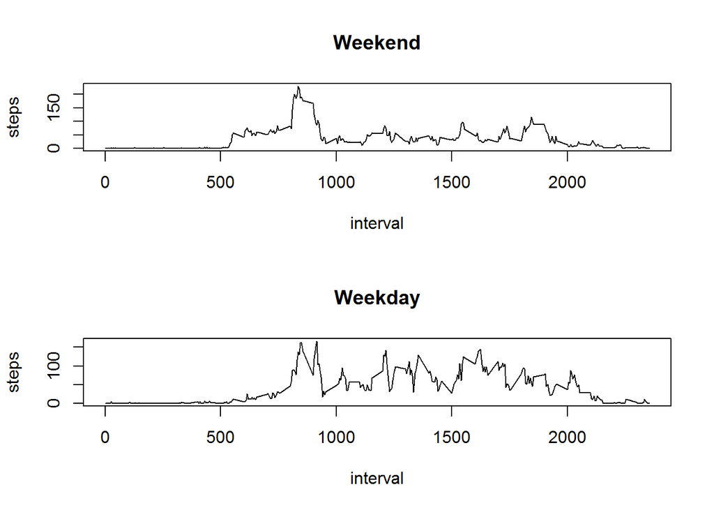

### Addendum

Another approach for imputing the missing values would have been to use the following logic:

1. If data for an entire day is missing, use the averaged daily activity pattern calculated in Question 2.
2. If data for an interval is missing, but there is other data for the day, use the averaged daily activity pattern multiplied by the average steps for that day divided by the averaged steps across all days.

This would have helped ensure that when *some* data was available for a given day, the day would have been given a more appropriate set of data for its missing values. That said, this is probably overkill for the level of analysis done here.